# R Notebook

Definir la medidad de distancias

Al final : tipos de distancias - numericas : - para datos mixtos : Groover

Hay formas de calcular distancias cuando solo hay datos categoricos

Si tuviera datos no estructurados , tambien se puede calcular distancias , por ejemplo numero de palabras entre distintos corpus

Tecnicas tradicionales de clustering

Particionales: Este tipo de algoritmos , forma clustering con datos excluyentes, los k grupos para agrupar los objetos no pueden interceptarse y la union de todos los grupo me da todo la poblacion

1.- definir el valor de k inicialmente. numero de conglomerados 2.- El algoritmo escoge un valor 3.- Se usa la k medias

Elegir los k centroides Cada objeto lo agrupa con el crentroide mas cercanos Se recalcula los centroides

Si tengo outlier : transformar las variables pero se modifican los grupos, se usa la estandarizacion

La convergencia

```r
# Instalaci?n de Paquetes
install.packages(c("cluster","fpc","mclust","flexmix","prabclus","diptest","trimcluster","plyr","modeltools","mvtnorm","robustbase","kernlab"),dependencies = c("Depends"))
```

```
Error in install.packages : Updating loaded packages
```

#=======================================================# # Metodos Particionales # #=======================================================#

# K-Medias

#——————————————————-# # Simulacion # #——————————————————-#

k-medias : es no supervisados

No se ha estandarizado los datos,

```r
#Semilla para replicar resultados
set.seed(007)

x=cbind(rnorm(100,1000,100),
        c(rnorm(50),rnorm(50,10,1)))
```

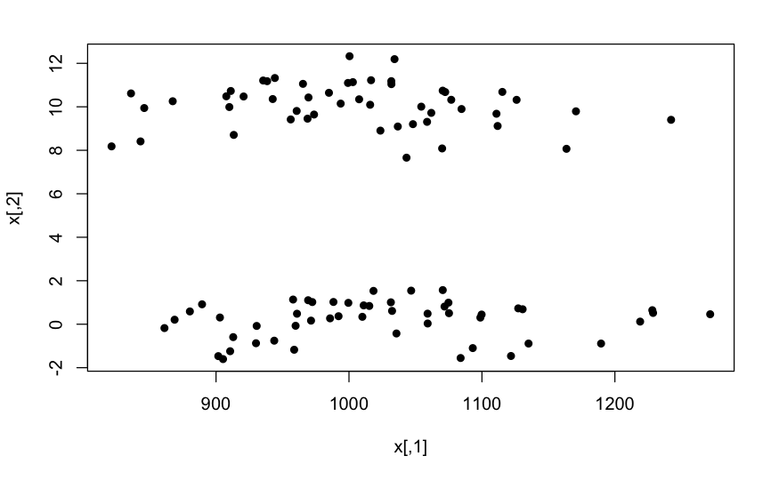

```r
# se tiene visualmente 2 conglomerados
plot(x,pch=16)
```

Se busca 2 conglomerados

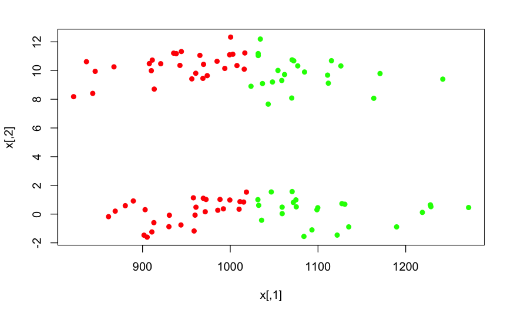

```r
#k-means datos originales
res=kmeans(x,2)
#res$cluster
plot(x,col=c("green","red")[res$cluster],pch=16)
```

Se observa que no es lo esperado , pero es tema es la distancia horizontal a la vertical, para poder hacer mejor debemos estandarizar

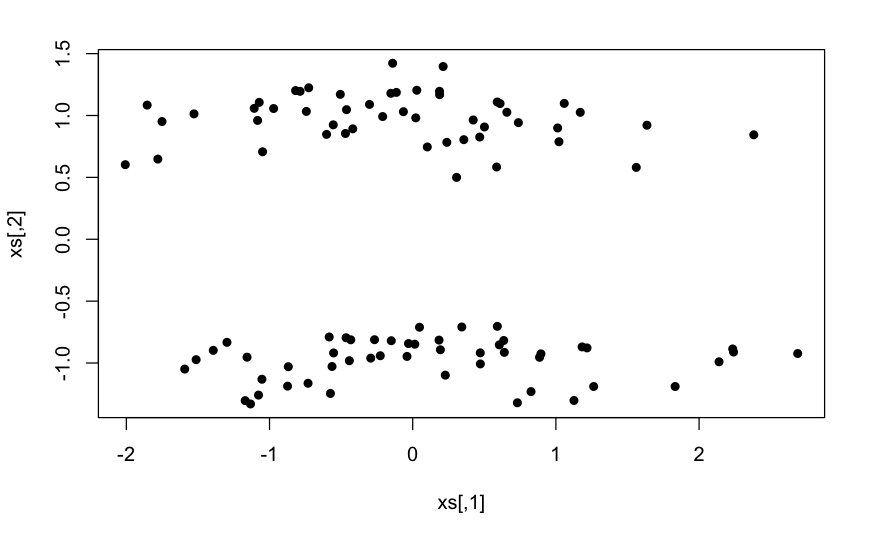

```r
# Estandarizacion
xs=scale(x)
plot(xs,pch=16)
```

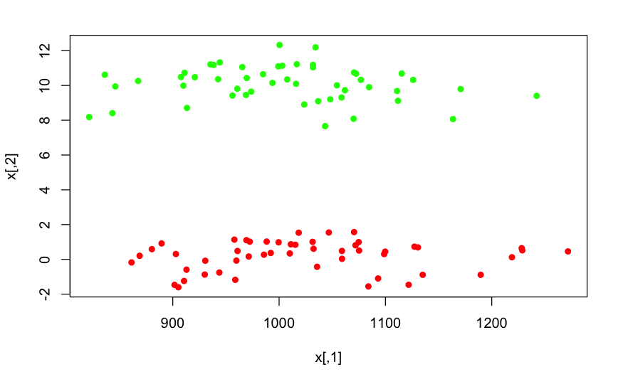

```r
#k-means datos estandarizados
res=kmeans(xs,2)
plot(x,col=c("green","red")[res$cluster],pch=16)
```

Se ve que estan los 2 conglomerados esperados, pero es porque sabiamos que buscabamos los 2 conglomerados #——————————————————-# # Ejemplo distritos # #——————————————————-#

```r
library(foreign)
distritos=read.spss("distritos.sav",use.value.labels=TRUE, max.value.labels=Inf, to.data.frame=TRUE)
```

```
re-encoding from CP1252
```

```r
View(distritos)
```

```r
colnames(distritos) <- tolower(colnames(distritos))
nombres=distritos[,1]
distritos=distritos[,-1]
rownames(distritos)=nombres
head(distritos)
```

|  | ocu_vivi | pobpjov | sinelect | sinagua | pea1619 | pocprin | peam15 |
| --- | --- | --- | --- | --- | --- | --- | --- |
| Ate | 1.15 | 5.3 | 27.60 | 51.10 | 3.9 | 1.1 | 63.48 |
| Barranco | 1.09 | 4.5 | 1.59 | 8.32 | 0.8 | 3.9 | 33.48 |
| Breña | 1.08 | 4.4 | 2.20 | 23.15 | 0.9 | 4.0 | 37.89 |
| Carabayllo | 1.10 | 5.1 | 30.13 | 38.09 | 4.5 | 12.6 | 63.65 |
| Comas | 1.20 | 5.9 | 10.92 | 24.27 | 3.8 | 9.4 | 60.37 |
| Chorrillos | 1.15 | 5.5 | 16.77 | 37.11 | 3.2 | 10.6 | 18.78 |

Aplicamos la tecnica de k medias

```r
res<-kmeans(scale(distritos),2)
res
```

```
K-means clustering with 2 clusters of sizes 19, 15

Cluster means:
    ocu_vivi    pobpjov   sinelect    sinagua    pea1619    pocprin     peam15
1 -0.5238407 -0.5949751 -0.7071806 -0.6300979 -0.7877401 -0.6061537 -0.6647556
2  0.6635316  0.7536352  0.8957621  0.7981240  0.9978041  0.7677947  0.8420238

Clustering vector:
Ate                            Barranco
                             2                              1
Breña                          Carabayllo
                             1                              2
Comas                          Chorrillos
                             2                              2
Agustino                       Independencia
                             2                              2
Jesús María                    La Victoria
                             1                              1
Lima                           Lince
                             1                              1
Los Olivos                     Lurigancho-Chosica
                             2                              2
Magdalena del Mar              Pueblo Libre
                             1                              1
Miraflores                     Rímac
                             1                              1
San Borja                      San Isidro
                             1                              1
San Juan de Lurigancho         San Juan de Miraflores
                             2                              2
San Luis                       San Martin de Porres
                             1                              2
San Miguel                     Santa Anita
                             1                              2
Surco                          Surquillo
                             1                              1
Villa el Salvador              Villa María del Triunfo
                             2                              1
Callao                         Carmen de la Legua
                             2                              2
La Perla                       La Punta
                             1                              1

Within cluster sum of squares by cluster:
[1] 36.46842 67.25282
 (between_SS / total_SS =  55.1 %)

Available components:

[1] "cluster"      "centers"      "totss"        "withinss"     "tot.withinss"
[6] "betweenss"    "size"         "iter"         "ifault"
```

## Se tiene los componentes:

[1] “cluster” “centers” “totss” “withinss” “tot.withinss” [6] “betweenss” “size” “iter” “ifault”

```r
res$betweenss
```

```
[1] 127.2788
```

```r
# suma de cuadratos dentro del cluster
res$withins
```

```
[1] 36.46842 67.25282
```

```r
# suma total de los cuadratos
res$tot.withins
```

```
[1] 103.7212
```

Si fuera 0, la distancia entre los centroides es cero

```r
#
res$totss
```

```
[1] 231
```

Porque elegir k = 2 ?, se debe revisar

Una manera intuititva , un conglomerados es mejor cuando tengo una menor suma de cuadrados dentro de los cluster, eso significa que la solucion es mejor.

Si al aumentar el numero de cluster, podria reductirse los datos en los conglomerados y la distancia ideal seria 0 cuando un conglomerado tenga un solo dato

#————————————# # Determinar numero de conglomerados # #————————————#

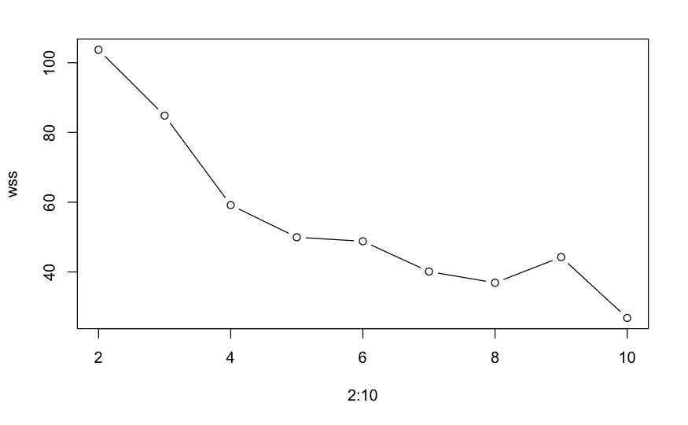

```r
# Suma de cuadrados dentro de clusters
wss<-numeric()
for(h in 2:10){
  b<-kmeans(scale(distritos),h) # esta estandarizando
  wss[h-1]<-b$tot.withinss
}

plot(2:10,wss,type="b")
```

El algoritmo de k-medias no converge y puede generar varias soluciones

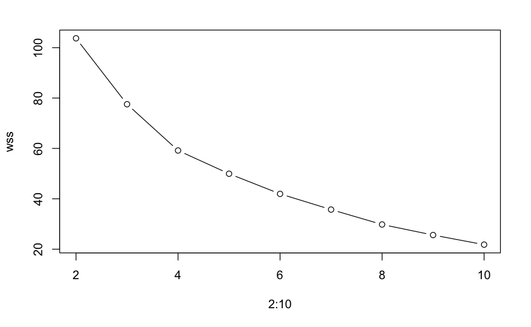

```r
# Suma de cuadrados dentro de clusters
wss<-numeric()
for(h in 2:10){
  b<-kmeans(scale(distritos),h, nstart= 100) # esta estandarizando
  wss[h-1]<-b$tot.withinss
}

plot(2:10,wss,type="b")
```

En esta grafica sedimentario se tiene que ver entre quienes la diferencia es mayor en la agrupacion de conglomerados. puede ser entre 2 o 3 ; 3 o 4

# Silueta

Mas tiende a 1 esta mejor conglomerados Si se aleja a 1 no es bueno , Si es negativo que tiene un objeto en ese grupo que se parece maa otros conglomerados

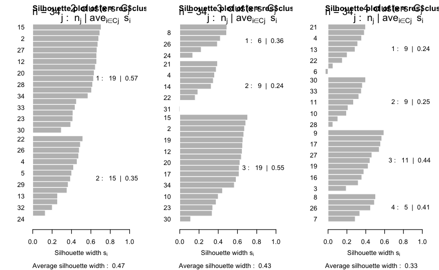

```r
library(cluster)

diss.distritos=daisy(scale(distritos)) # calculo la matriz de disimilidad
par(mfrow=c(1,3))
for(h in 2:4){
  res=kmeans(scale(distritos),h, nstart= 100) # encuentra la solucion mas optima
  plot(silhouette(res$cluster,diss.distritos)) # la distancia que has aplicado en k medias
}
par(mfrow=c(1,1))
```

Criterio de Calinski-Harabasz

```
|  .
|   .
|    .
|     .
```

```
|              .
|             .
|            .
```

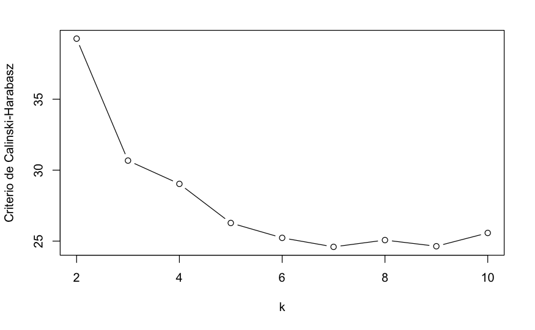

```r
# Criterio de Calinski-Harabasz
library(fpc)
ch<-numeric()
for(h in 2:10){
  res<-kmeans(scale(distritos),h,nstart = 100)
  ch[h-1]<-calinhara(scale(distritos),res$cluster)
}
plot(2:10,ch,type="b",xlab="k",
     ylab="Criterio de Calinski-Harabasz")
```

```r
kmeansruns(scale(distritos),criterion="ch")
```

```
K-means clustering with 2 clusters of sizes 19, 15

Cluster means:
    ocu_vivi    pobpjov   sinelect    sinagua    pea1619    pocprin     peam15
1 -0.5238407 -0.5949751 -0.7071806 -0.6300979 -0.7877401 -0.6061537 -0.6647556
2  0.6635316  0.7536352  0.8957621  0.7981240  0.9978041  0.7677947  0.8420238

Clustering vector:
Ate                            Barranco
                             2                              1
Breña                          Carabayllo
                             1                              2
Comas                          Chorrillos
                             2                              2
Agustino                       Independencia
                             2                              2
Jesús María                    La Victoria
                             1                              1
Lima                           Lince
                             1                              1
Los Olivos                     Lurigancho-Chosica
                             2                              2
Magdalena del Mar              Pueblo Libre
                             1                              1
Miraflores                     Rímac
                             1                              1
San Borja                      San Isidro
                             1                              1
San Juan de Lurigancho         San Juan de Miraflores
                             2                              2
San Luis                       San Martin de Porres
                             1                              2
San Miguel                     Santa Anita
                             1                              2
Surco                          Surquillo
                             1                              1
Villa el Salvador              Villa María del Triunfo
                             2                              1
Callao                         Carmen de la Legua
                             2                              2
La Perla                       La Punta
                             1                              1

Within cluster sum of squares by cluster:
[1] 36.46842 67.25282
 (between_SS / total_SS =  55.1 %)

Available components:

 [1] "cluster"      "centers"      "totss"        "withinss"     "tot.withinss"
 [6] "betweenss"    "size"         "iter"         "ifault"       "crit"
[11] "bestk"
```

```r
kmeansruns(scale(distritos),criterion="asw")
```

```
K-means clustering with 2 clusters of sizes 15, 19

Cluster means:
    ocu_vivi    pobpjov   sinelect    sinagua    pea1619    pocprin
1  0.6635316  0.7536352  0.8957621  0.7981240  0.9978041  0.7677947
2 -0.5238407 -0.5949751 -0.7071806 -0.6300979 -0.7877401 -0.6061537
      peam15
1  0.8420238
2 -0.6647556

Clustering vector:
Ate                            Barranco
                             1                              2
Breña                          Carabayllo
                             2                              1
Comas                          Chorrillos
                             1                              1
Agustino                       Independencia
                             1                              1
Jesús María                    La Victoria
                             2                              2
Lima                           Lince
                             2                              2
Los Olivos                     Lurigancho-Chosica
                             1                              1
Magdalena del Mar              Pueblo Libre
                             2                              2
Miraflores                     Rímac
                             2                              2
San Borja                      San Isidro
                             2                              2
San Juan de Lurigancho         San Juan de Miraflores
                             1                              1
San Luis                       San Martin de Porres
                             2                              1
San Miguel                     Santa Anita
                             2                              1
Surco                          Surquillo
                             2                              2
Villa el Salvador              Villa María del Triunfo
                             1                              2
Callao                         Carmen de la Legua
                             1                              1
La Perla                       La Punta
                             2                              2

Within cluster sum of squares by cluster:
[1] 67.25282 36.46842
 (between_SS / total_SS =  55.1 %)

Available components:

 [1] "cluster"      "centers"      "totss"        "withinss"
 [5] "tot.withinss" "betweenss"    "size"         "iter"
 [9] "ifault"       "crit"         "bestk"
```

================== Se recomienda usar 3 indicadores, si son distintos podrian ser que tengas que usar estandarizacion o simplemente no aplicar conglomerados

========= Se realiza un analisis descriptivo de los conglomerados

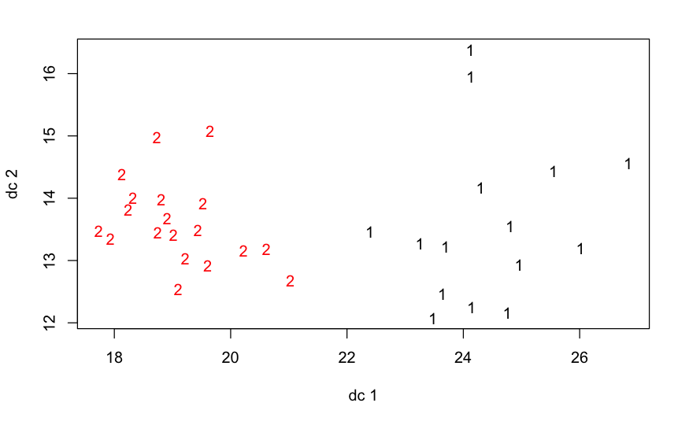

```r
res=kmeans(scale(distritos),2)
plotcluster(distritos,res$cluster)
```

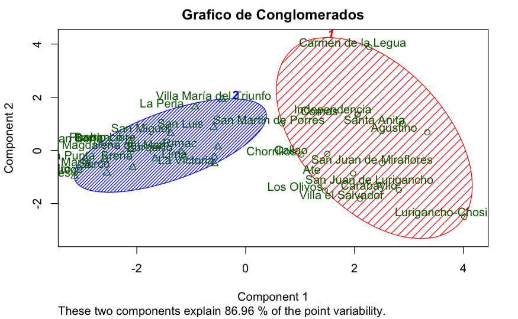

```r
clusplot(distritos,res$cluster, color = TRUE,
         shade = TRUE, labels =2,lines=0,
         main ="Grafico de Conglomerados")
```

```r
#-----------------------------------------#
# Perfilado y caracterizaci?n de clusters #
#-----------------------------------------#

# Adicionar los cluster a la base de datos
distritos.new<-cbind(distritos,res$cluster)
#print(colnames(distritos.new))
#print(length(distritos.new))
#print(colnames(distritos.new[,-length(distritos.new)]))
colnames(distritos.new)<-c(colnames(distritos.new[,-length(distritos.new)]), "cluster.km")
head(distritos.new)
```

|  | ocu_vivi | pobpjov | sinelect | sinagua | pea1619 | pocprin | peam15 | cluster.km |
| --- | --- | --- | --- | --- | --- | --- | --- | --- |
| Ate | 1.15 | 5.3 | 27.60 | 51.10 | 3.9 | 1.1 | 63.48 | 1 |
| Barranco | 1.09 | 4.5 | 1.59 | 8.32 | 0.8 | 3.9 | 33.48 | 2 |
| Breña | 1.08 | 4.4 | 2.20 | 23.15 | 0.9 | 4.0 | 37.89 | 2 |
| Carabayllo | 1.10 | 5.1 | 30.13 | 38.09 | 4.5 | 12.6 | 63.65 | 1 |
| Comas | 1.20 | 5.9 | 10.92 | 24.27 | 3.8 | 9.4 | 60.37 | 1 |
| Chorrillos | 1.15 | 5.5 | 16.77 | 37.11 | 3.2 | 10.6 | 18.78 | 1 |

```r
# Tabla de medias
med<-aggregate(x = distritos.new[,1:7],by = list(distritos.new$cluster.km),FUN = mean)
med
```

| Group.1 | ocu_vivi | pobpjov | sinelect | sinagua | pea1619 | pocprin | peam15 |
| --- | --- | --- | --- | --- | --- | --- | --- |
| 1 | 1.160000 | 5.520000 | 18.856000 | 37.02400 | 3.7946667 | 9.780000 | 56.84000 |
| 2 | 1.080526 | 4.631579 | 2.447895 | 15.80895 | 0.8736842 | 5.057895 | 32.16526 |

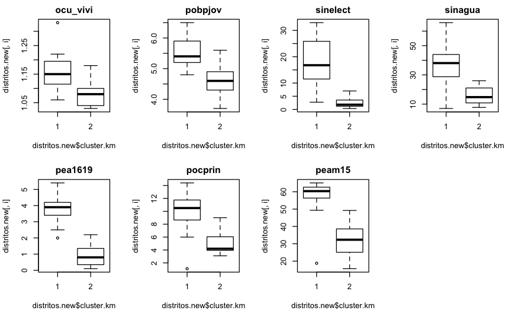

```r
# Describir variables
par(mfrow=c(2,4))
for (i in 1:length(distritos.new[,1:7])) {
  boxplot(distritos.new[,i]~distritos.new$cluster.km, main=names(distritos.new[i]), type="l")
}
par(mfrow=c(1,1))
```

Si se ven diferencias es que los conglomerados han sido elegidos adecuadamente

Como alternativa a K - medias

- K medias se afecta por los outlier

Se usa K - medoide : metodoo que elije un objeto que rempresenta a todos los objetos

El algoritmo que usa el medoides es el PAM ( Particionamiento Alrededor del Medoide)

BUILD : - Elegir al azar los k medoides - Ver que cada observacion que distancia tiene con lo k medoides, lo agrupas con las distancia del medoide mas cercanos -

SWAP: - Le doy medoides alternativo que esten en conglomerados distintos

Medida de disimilidad –> distancia mas cercana al medoide

Si PAM me sale igual que K-medias , eso significa que no hay outlier

# PAM

```r
# library(cluster)
# data(iris)
# a=pam(iris[,1:4],3,diss=F)
# a$clustering
# table(a$clustering)
# table(a$clustering,iris[,5])
#
# library(arules)
# data(AdultUCI)
# censusn<-AdultUCI
# census<-na.omit(censusn)
# census<-as.data.frame(census[1:1000,])
# b<-daisy(census[,-15])
# summary(b)
# a=pam(b,2,diss=T)
# a$clustering
# table(a$clustering)
# table(a$clustering,census[1:1000,15])

res=pam(scale(distritos),2)
res
```

```
Medoids:
                               ID   ocu_vivi    pobpjov   sinelect    sinagua    pea1619    pocprin
San Juan de Miraflores         22  0.5141271  0.5714769  1.0211988  1.1196499  1.2455772  1.0645749
Magdalena del Mar              15 -0.5317041 -0.7947101 -0.8085748 -0.6737858 -0.8939102 -0.8848637
                                   peam15
San Juan de Miraflores          0.9067534
Magdalena del Mar              -0.8586552
Clustering vector:
Ate                            Barranco                       Breña
                             1                              2                              2
Carabayllo                     Comas                          Chorrillos
                             1                              1                              1
Agustino                       Independencia                  Jesús María
                             1                              1                              2
La Victoria                    Lima                           Lince
                             2                              2                              2
Los Olivos                     Lurigancho-Chosica             Magdalena del Mar
                             1                              1                              2
Pueblo Libre                   Miraflores                     Rímac
                             2                              2                              2
San Borja                      San Isidro                     San Juan de Lurigancho
                             2                              2                              1
San Juan de Miraflores         San Luis                       San Martin de Porres
                             1                              2                              1
San Miguel                     Santa Anita                    Surco
                             2                              1                              2
Surquillo                      Villa el Salvador              Villa María del Triunfo
                             2                              1                              2
Callao                         Carmen de la Legua             La Perla
                             1                              1                              2
La Punta
                             2
Objective function:
   build     swap
1.648834 1.598154

Available components:
 [1] "medoids"    "id.med"     "clustering" "objective"  "isolation"  "clusinfo"   "silinfo"
 [8] "diss"       "call"       "data"
```

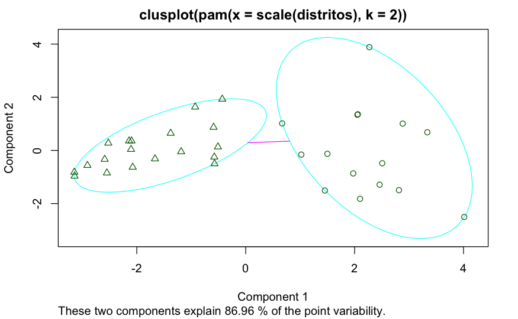

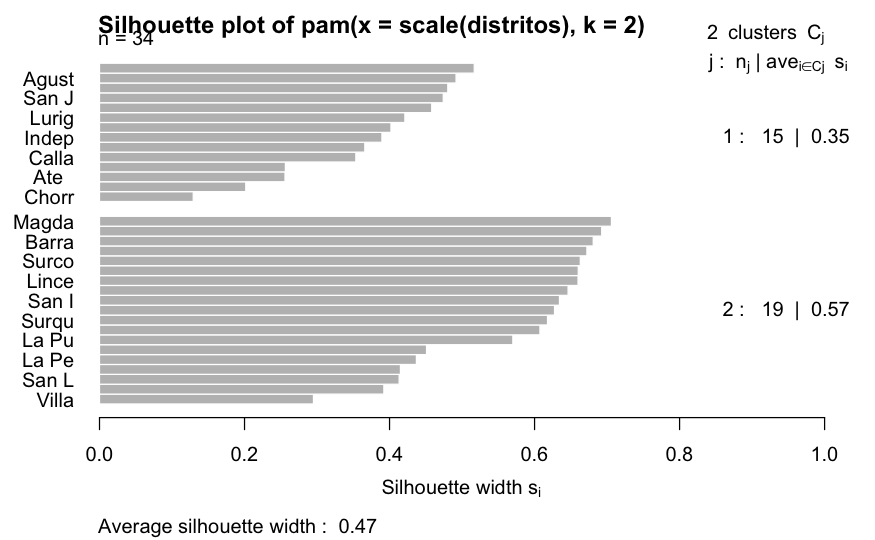

```r
plot(res)
```

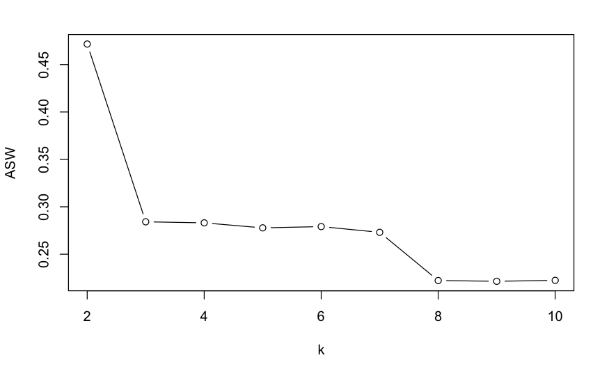

```r
asw<-numeric()

for(h in 2:10){
  res<-pam(scale(distritos),h)
  asw[h-1]<-res$silinfo$avg.width
}

plot(2:10,asw,type="b",xlab="k",ylab="ASW")
```

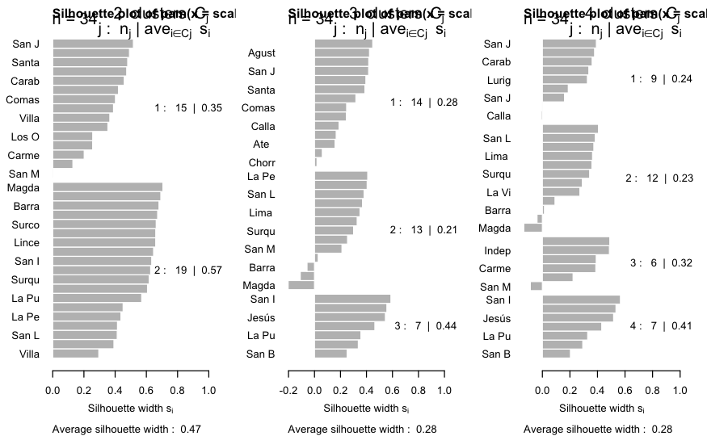

```r
par(mfrow=c(1,3))
for(h in 2:4){
  res=pam(scale(distritos),h)
  plot(res,which.plots=2)
}
```

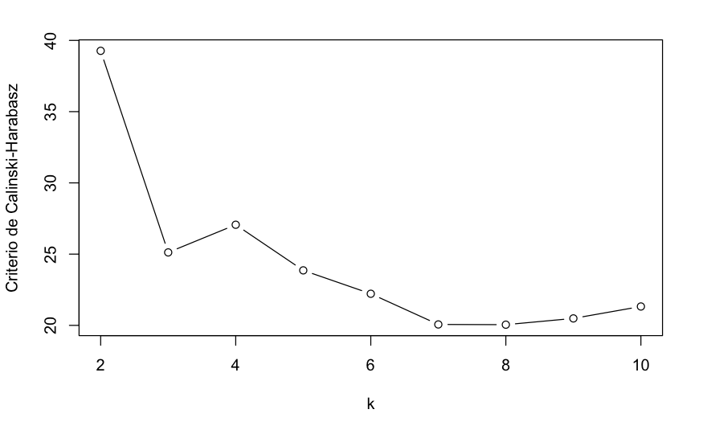

```r
par(mfrow=c(1,1))
ch<-numeric()
for(h in 2:10){
  res<-pam(scale(distritos),h)
  ch[h-1]<-calinhara(scale(distritos),res$clustering)
}
plot(2:10,ch,type="b",xlab="k",
ylab="Criterio de Calinski-Harabasz")
```

```r
pamk(scale(distritos),criterion="asw")
```

```
$pamobject
Medoids:
                               ID   ocu_vivi    pobpjov   sinelect    sinagua    pea1619    pocprin
San Juan de Miraflores         22  0.5141271  0.5714769  1.0211988  1.1196499  1.2455772  1.0645749
Magdalena del Mar              15 -0.5317041 -0.7947101 -0.8085748 -0.6737858 -0.8939102 -0.8848637
                                   peam15
San Juan de Miraflores          0.9067534
Magdalena del Mar              -0.8586552
Clustering vector:
Ate                            Barranco                       Breña
                             1                              2                              2
Carabayllo                     Comas                          Chorrillos
                             1                              1                              1
Agustino                       Independencia                  Jesús María
                             1                              1                              2
La Victoria                    Lima                           Lince
                             2                              2                              2
Los Olivos                     Lurigancho-Chosica             Magdalena del Mar
                             1                              1                              2
Pueblo Libre                   Miraflores                     Rímac
                             2                              2                              2
San Borja                      San Isidro                     San Juan de Lurigancho
                             2                              2                              1
San Juan de Miraflores         San Luis                       San Martin de Porres
                             1                              2                              1
San Miguel                     Santa Anita                    Surco
                             2                              1                              2
Surquillo                      Villa el Salvador              Villa María del Triunfo
                             2                              1                              2
Callao                         Carmen de la Legua             La Perla
                             1                              1                              2
La Punta
                             2
Objective function:
   build     swap
1.648834 1.598154

Available components:
 [1] "medoids"    "id.med"     "clustering" "objective"  "isolation"  "clusinfo"   "silinfo"
 [8] "diss"       "call"       "data"

$nc
[1] 2

$crit
 [1] 0.0000000 0.4716626 0.2841849 0.2830814 0.2777934 0.2791337 0.2730802 0.2222431 0.2214481 0.2224316
```

## Funcion objetivos:

build swap 1.648834 1.598154

Empezo con 1.648834 y luego acabo con 1.598154

EL conglomerado es un metodo multivariado

```r
pamk(scale(distritos),criterion="ch")
```

```
$pamobject
Medoids:
                               ID   ocu_vivi    pobpjov   sinelect    sinagua    pea1619    pocprin
San Juan de Miraflores         22  0.5141271  0.5714769  1.0211988  1.1196499  1.2455772  1.0645749
Magdalena del Mar              15 -0.5317041 -0.7947101 -0.8085748 -0.6737858 -0.8939102 -0.8848637
                                   peam15
San Juan de Miraflores          0.9067534
Magdalena del Mar              -0.8586552
Clustering vector:
Ate                            Barranco                       Breña
                             1                              2                              2
Carabayllo                     Comas                          Chorrillos
                             1                              1                              1
Agustino                       Independencia                  Jesús María
                             1                              1                              2
La Victoria                    Lima                           Lince
                             2                              2                              2
Los Olivos                     Lurigancho-Chosica             Magdalena del Mar
                             1                              1                              2
Pueblo Libre                   Miraflores                     Rímac
                             2                              2                              2
San Borja                      San Isidro                     San Juan de Lurigancho
                             2                              2                              1
San Juan de Miraflores         San Luis                       San Martin de Porres
                             1                              2                              1
San Miguel                     Santa Anita                    Surco
                             2                              1                              2
Surquillo                      Villa el Salvador              Villa María del Triunfo
                             2                              1                              2
Callao                         Carmen de la Legua             La Perla
                             1                              1                              2
La Punta
                             2
Objective function:
   build     swap
1.648834 1.598154

Available components:
 [1] "medoids"    "id.med"     "clustering" "objective"  "isolation"  "clusinfo"   "silinfo"
 [8] "diss"       "call"       "data"

$nc
[1] 2

$crit
 [1]  0.00000 39.26795 25.11968 27.06260 23.85990 22.21844 20.06436 20.04850 20.48795 21.32444
```

Los medoides son:

- San Juan de Miraflores
- Magdalena del Mar

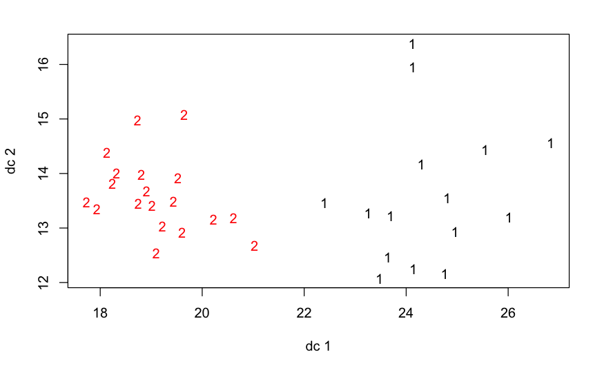

```r
res=pam(scale(distritos),2)
plotcluster(distritos,res$clustering)
```